# Programming: Conditionals, Loops, Custom Functions

Enrico Toffalini

## **`if`** statement

automatically make decisions based on boolean value of a condition

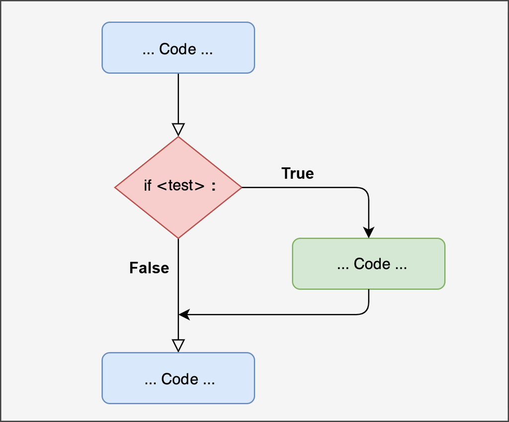

## Conditional Programming

The logic closely resembles that in R, except that Python uses **indentation** (**not** curly or round brackets) to define blocks of code

### **`if`** statement

Performs an action *only if* a condition is met:

```python
age = 20

if age >= 18:
    print("Adult")
```

```
Adult
```

## `if...else` statement

Sometimes you need to perform *alternative, mutually-exclusive* actions:

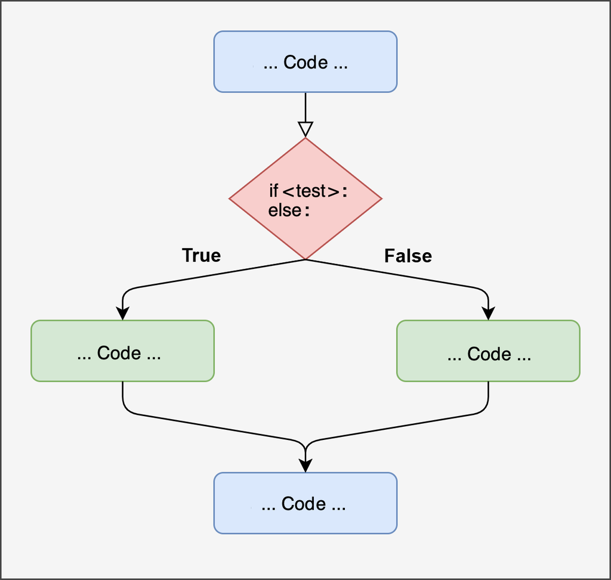

## `if...else` statement

```python
age = 15

if age >= 18:
    print("Adult")
else:
    print("Minor")
```

```
Minor
```

Note that **indentation** is really important!

```python
age = 15

if age >= 18:
    print("Adult")
else:
print("Minor")
```

```
expected an indented block after 'else' statement on line 5 (<string>, line 6)
```

## `if...elif...else` statement

When you need to evaluate more than just two alternative conditions, you can use sort of *nested conditional statements* with with `if...elif...else`

```python
age = 10

if age >= 18:
    print("Adult")
elif age >= 13:
    print("Adolescent")
elif age >= 2:
    print("Child")
else:
    print("Infant")
```

```
Child
```

## Example: Preplanned Analysis

Hypothetical **automated decision** in a **pre-registered analysis pipeline**:

```python
import numpy as np
import scipy.stats as st

x1 = np.random.normal(0, 1, size=30)
x2 = np.random.normal(0.5, 1, size=30)

tt = st.ttest_ind(x1, x2)
pval = tt.pvalue.round(4)
print(pval)
```

```
0.7353
```

```python
if pval < 0.05:
    print("Significant result: proceeding with follow-up analysis")
    # ...here you could perform other analyses after the preliminary check
else:
    print("No significant result: reporting preliminary test only")
```

```
No significant result: reporting preliminary test only
```

### Vectorized and Nested conditions

All previous examples evaluated **a single statement** that may be **`True`** or **`False`**. However, you often want to apply this operation to an entire vector

```python
agesVector = np.array([2, 28, 15, 11, 4, 67, 0, 42, 14, 8])

if agesVector >= 18:
    print("Adult")
else:
    print("Minor")
```

```
ValueError: The truth value of an array with more than one element is ambiguous. Use a.any() or a.all()
```

*the error message suggests that I might use `np.any(agesVector >= 18)` or `np.all(agesVector >= 18)`, but this is not what I want! What I want is actually an `if...else` that evaluates across a whole vector of `True`s and `False`s (which should be like the `ifelse()` in R)*

### Vectorized and Nested conditions

You could use *list comprehension* (more on this later!), but it’s a bit **painful to write**, **less readable**, and **slower** (for large data)…

```python
agesVector = np.array([2, 28, 15, 11, 4, 67, 0, 42, 14, 8])

["adult" if age >= 18 else "minor" for age in agesVector]
```

```
['minor', 'adult', 'minor', 'minor', 'minor', 'adult', 'minor', 'adult', 'minor', 'minor']
```

### Vectorized and Nested conditions

**`np.where()`** *(manages one single condition, similar to `ifelse()` in R)*

```python
agesVector = np.array([2, 28, 15, 11, 4, 67, 0, 42, 14, 8])

np.where(agesVector >= 18, "Adult", "Minor")
```

```
array(['Minor', 'Adult', 'Minor', 'Minor', 'Minor', 'Adult', 'Minor',
       'Adult', 'Minor', 'Minor'], dtype='<U5')
```

**`np.select()`** *(multiple nested conditions, like `dplyr::case_when()` in R)*

```python
conditions = [agesVector >= 18, agesVector >= 13,
                            agesVector >= 2, agesVector >= 0]
choices = ["Adult", "Adolescent", "Child", "Infant"]

np.select(conditions, choices, default="")
```

```
array(['Child', 'Adult', 'Adolescent', 'Child', 'Child', 'Adult',
       'Infant', 'Adult', 'Adolescent', 'Child'], dtype='<U10')
```

## Loops in Python

Looping in Python is used to repeat actions: `for` and `while` are most common

### `for` loop basics

```python
for i in range(5):
    print(i)
```

```
0
1
2
3
4
```

```python
for i in range(5):
    print(i**2)
```

```
0
1
4
9
16
```

### Time-based iteration

```python
import time

for i in range(5):
    print(time.time())
    time.sleep(1)
```

```
1748966362.699327
1748966363.6996806
1748966364.7001276
1748966365.7013485
1748966366.7020855
```

## Loops in Python - Monte Carlo Simulation 😃

```python
from scipy.stats import ttest_ind
import numpy as np
np.random.seed(111) # set seed for reproducibility: best practice!
N = 50
niter = 10
effsize= 0.3
pvalues = np.empty(niter) # initialize empty vector: best practice!

for i in range(niter):
    x1 = np.random.normal(0, 1, size=N)
    x2 = np.random.normal(effsize, 1, size=N)
    tt = ttest_ind(x1,x2)
    pvalues[i] = tt.pvalue.round(3)

print(pvalues)
```

```
[0.047 0.004 0.002 0.117 0.009 0.26  0.463 0.004 0.195 0.   ]
```

```python
print(np.mean(pvalues < 0.05))
```

```
0.6
```

## Loops in Python - Monte Carlo Simulation 😃

```python
from scipy.stats import ttest_ind
import numpy as np
np.random.seed(111)
N = 50
niter = 10000
effsize= 0.3
pvalues = np.empty(niter)

for i in range(niter):
    x1 = np.random.normal(0, 1, size=N)
    x2 = np.random.normal(effsize, 1,
                                size=N)
    tt = ttest_ind(x1,x2)
    pvalues[i] = tt.pvalue

# ESTIMATE POWER
print(np.mean(pvalues < 0.05))
```

```
0.3194
```

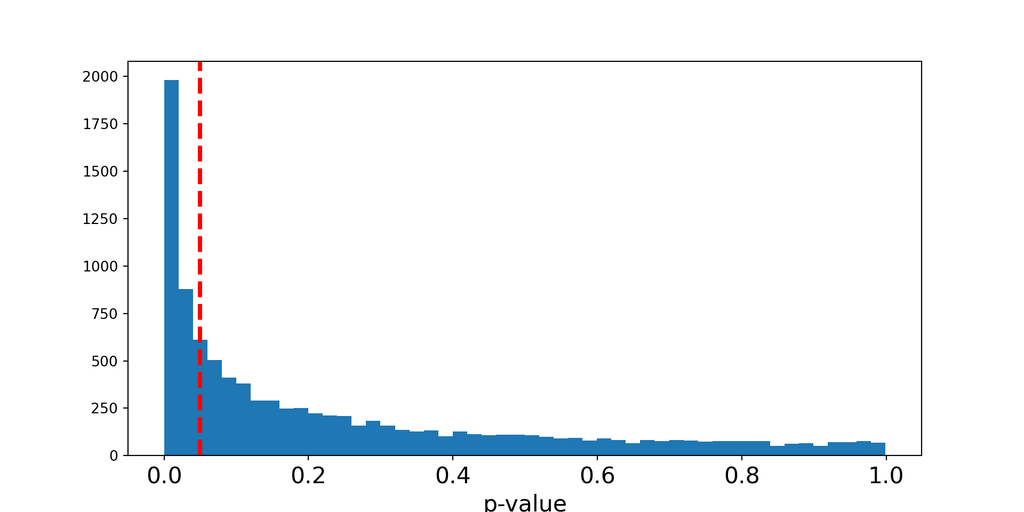

```python
# PLOT RESULTS

import matplotlib.pyplot as plt

plt.hist(pvalues, bins=50)
plt.axvline(0.05, color='red',
          linestyle='--', linewidth=3)
plt.xticks(fontsize=16);
plt.xlabel("p-value",fontsize=16)

plt.show()
```

## Iterating over Elements

Iterating using an integer index in a range (“`i in range(niter)`” is a common practice, but you can also iterate directly over the elements of a *List* or other data structures (even *Strings*)

```python
words = ["this", "is", "a",
        "vector", "of", "strings"]
for w in words:
    print(w.upper()*2)
```

```
THISTHIS
ISIS
AA
VECTORVECTOR
OFOF
STRINGSSTRINGS
```

```python
word = "ciao"
for lett in word:
    print(lett*5)
```

```
ccccc
iiiii
aaaaa
ooooo
```

*List comprehension* is another, compact type of *for* loop over list elements:

```python
[w.upper()*2 for w in words]
```

```
['THISTHIS', 'ISIS', 'AA', 'VECTORVECTOR', 'OFOF', 'STRINGSSTRINGS']
```

## `while` loop

The `while` loop is another classical type of iterative structure. It is useful when the precise number of iterations is unknown *a priori*, and depends on a condition becoming `True`

```python
amount = 1000
month = 0
interest_rate = 0.001

while amount < 1500:
    month += 1
    amount += amount * interest_rate

print(month)
```

```
406
```

➜ *it takes 406 months to reach an amount of €$1,500$ when starting with an amount of €$1,000$ with a 0.1% monthly interest rate*

## `break` in loops

The `break` command allows to interrupt any loop based on a condition

```python
import time
import scipy.stats as st

attempts = 0
pval = 1
Start = time.time()
while pval >= 0.001: # go on until p < 0.001
  attempts += 1
  x1 = np.random.normal(0,1,size=30)
  x2 = np.random.normal(0,1,size=30)
  tt = st.ttest_ind(x1, x2)
  pval = tt.pvalue
  Now = time.time()
  if Now - Start > 10:
    break            # however, stop if overall time exceeds 10 seconds
print([attempts, pval.round(4)])
```

```
[152, np.float64(0.0007)]
```

## Other iteration: `for` with `zip()`

**`zip()`** pairs elements across multiple sequences while iterating them

```python
numbers = [5, 10, 10, 2, 7]


for n in numbers:
   print(n**2)
```

```
25
100
100
4
49
```

```python
numbers = [5, 10, 10, 2, 7]
exponents = [2, 1, 5, 3, 1]

for n, e in zip(numbers, exponents):
   print(n**e)
```

```
25
10
100000
8
7
```

```python
[n**e for n, e in zip(numbers, exponents)]
```

```
[25, 10, 100000, 8, 7]
```

*but note that the latter could be obtained much more easily with `numpy` vectorized operations: **`np.array(numbers) ** np.array(exponents)`***

## Other iteration: `for` with `zip()`

**`zip()`** pairs elements across multiple sequences while iterating them

```python
teacher = ["Pastore", "Granziol", "Feraco","Altoe"]
course = ["CurrentIssues", "BasicsInference", "SEM","Outliers"]
hours = [10, 20, 20, 5]

for t, c, h in zip(teacher, course, hours):
   print(f"{t} teaches {c} which has {h} hours") # formatted-string
```

```
Pastore teaches CurrentIssues which has 10 hours
Granziol teaches BasicsInference which has 20 hours
Feraco teaches SEM which has 20 hours
Altoe teaches Outliers which has 5 hours
```

## Other iteration: `for` with `zip()`

**`zip()`** is very convenient, but if really you don’t like it, you could do the same task using the classical numerical iterator **`i`**

```python
teacher = ["Pastore", "Granziol", "Feraco","Altoe"]
course = ["CurrentIssues", "BasicsInference", "SEM","Outliers"]
hours = [10, 20, 20, 5]

for i in range(len(teacher)):
   print(f"{teacher[i]} teaches {course[i]} which has {hours[i]} hours")
```

```
Pastore teaches CurrentIssues which has 10 hours
Granziol teaches BasicsInference which has 20 hours
Feraco teaches SEM which has 20 hours
Altoe teaches Outliers which has 5 hours
```

## Other iteration: `map()`

**`map()`** applies a specific function to each item in a sequence:

```python
x = ["apple", "banana", [1,2,3,4], "watermelon"]
result = map(len, x)

list(result)
```

```
[5, 6, 4, 10]
```

in `map()`, you need to use `list(...)` to actually generate the result, otherwise a non-evaluated “lazy” `map` object is obtained

`zip()` and `map()` are about equivalent to `lapply()`/`sapply()` in R

## Custom Functions

Custom functions are widely used in Python for efficiently reusing chunks of code. *Define* your functions with **`def`**; the logic is very similar as in R:

```python
def zScore(vect):
     vect = np.array(vect)
     mu = np.mean(vect)
     sigma = np.std(vect)
     return ((vect - mu) / sigma)

a = [10, 14, 7.6, 18, 22, 50, 0.5]
zScore(a).round(3)
```

```
array([-0.503, -0.233, -0.665,  0.038,  0.308,  2.201, -1.145])
```

```python
b = [700, 131, 215, 133.2, 190, 4100, 108.9]
zScore(b).round(3)
```

```
array([-0.071, -0.489, -0.427, -0.487, -0.446,  2.425, -0.505])
```

```python
c = [-4.2, -10.2, 2, -15]
zScore(c).round(3)
```

```
array([ 0.415, -0.525,  1.386, -1.277])
```

## Custom Functions with `def`

Let’s elaborate the custom `zScore` function a little bit, adding another arguments that allows us to specify whether we want to ignore *missing values*:

```python
def zScore(vect, naIgnore=False):
     vect = np.array(vect)
     if naIgnore==True:
           mu = np.nanmean(vect)
           sigma = np.nanstd(vect)
     else:
           mu = np.mean(vect)
           sigma = np.std(vect)
     return ((vect - mu) / sigma)


myVector = np.array([10, 14, 7.6, np.nan, 18, 22, 50, 0.5, np.nan, 1.4, 7])
zScore(myVector).round(2)
```

```
array([nan, nan, nan, nan, nan, nan, nan, nan, nan, nan, nan])
```

```python
zScore(myVector, naIgnore=True).round(2)
```

```
array([-0.32, -0.04, -0.49,   nan,  0.25,  0.53,  2.5 , -0.98,   nan,
       -0.92, -0.53])
```

## *Supercompact* Custom Functions with `lambda`

**`lambda`** command allows you to *define a custom function in a single line of code* without `def` or `return`; it may be useful for quick transformation, but of course does not allow any complex “logic” / statement

```python
myVector = np.array([10, 14, 7.6, 18, 22, 50, 0.5, 1.4, 7])

zScore = lambda x: (x - x.mean()) / x.std()

zScore(myVector)
```

```
array([-0.31638231, -0.03515359, -0.48511954,  0.24607513,  0.52730384,
        2.49590486, -0.98430051, -0.92102405, -0.52730384])
```

## *Supercompact* Custom Functions with `lambda`

**`lambda`** can take more than one argument

```python
myVector = np.array([10, 14, 7.6, 18, 22, 50, 0.5, 1.4, 7])

rescale = lambda x, m, s: ((x - x.mean()) / x.std()) * s + m

rescale(myVector, 100, 15)
```

```
array([ 95.25426541,  99.47269616,  92.72320696, 103.6911269 ,
       107.90955765, 137.43857287,  85.23549239,  86.18463931,
        92.09044235])
```

## Conditional programming: Python vs R

| Task | Python | R |
| --- | --- | --- |
| basic if | `if cond:` | `if(cond){ }` |
| if … else | `if cond:` `else:` | `if(cond){` `} else { }` |
| Multiple conditions | `if cond1:` `elif cond2:` `else:` | `if(cond1){` `} else if(cond2){` `} else { }` |
| Block delimiter | *indentation* | `{ }` |
| “*not*” elementwise | `~cond` | `!cond` |
| Multiple checks | `(a > 1) & (b < 5)` | `(a > 1) & (b < 5)` |
| Vectorized condition | `np.where(conds, ifT, ifF)` | `ifelse(conds, ifT, ifF)` |
| Multiple/nested vectorized conditions | `np.select([...], [...])` | `dplyr::case_when()` |

## Loops and Functions: Python vs R

| Task | Python | R |
| --- | --- | --- |
| Loop over integers | `for i in range(n):` | `for(i in 1:n){ }` |
| Loop over elements | `for a in A:` | `for(a in A){ }` |
| While loop | `while cond:` | `while(cond){ }` |
| Block delimiter | *indentation* | `{ }` |
| Break loop | `break` | `break` |
| Apply function (list) | `list(map(func, A))` | `lapply(A, func)` |
| Multilist iteration | `for a, b in zip(A, B):` | `mapply(FUN, A, B)` |
| List comprehension | `[func(a) for a in A]` | `lapply(...)` |
| Function | `def myFunc(a):` _____`...` _____`return ...` | `myFunc = function(a){ ... return(...)` `}` |
| Supercompact function | `lambda a: a + 1` | `function(a) a + 1` |